# Neural Networks

# Neural Networks

## Method 1: Neural Net

```r
modelLookup(model = "neuralnet")
```

```
##       model parameter                    label forReg forClass probModel
## 1 neuralnet    layer1 #Hidden Units in Layer 1   TRUE    FALSE     FALSE
## 2 neuralnet    layer2 #Hidden Units in Layer 2   TRUE    FALSE     FALSE
## 3 neuralnet    layer3 #Hidden Units in Layer 3   TRUE    FALSE     FALSE
```

This method has parameters to be tuned: layers 1 through 3 (i.e., three hidden layers within the black box).

```r
solar_nn1 <- train(kWh_m2 ~ ., data = solarRescale, method = "neuralnet")
solar_nn1
```

```
## Neural Network
##
## 119 samples
##  20 predictor
##
## No pre-processing
## Resampling: Bootstrapped (25 reps)
## Summary of sample sizes: 119, 119, 119, 119, 119, 119, ...
## Resampling results across tuning parameters:
##
##   layer1  RMSE       Rsquared   MAE
##   1       0.1596439  0.5990287  0.1169080
##   3       0.1579311  0.6456103  0.1163393
##   5       0.1625459  0.6451506  0.1197746
##
## Tuning parameter 'layer2' was held constant at a value of 0
## Tuning
##  parameter 'layer3' was held constant at a value of 0
## RMSE was used to select the optimal model using the smallest value.
## The final values used for the model were layer1 = 3, layer2 = 0 and layer3 = 0.
```

```r
# function to restore scaled values to original range of data
unscale <- function(x, maxim, minim) {
  y <- (x * (maxim - minim) + minim)
  return(y)
}
```

```r
set.seed(2337)
solar_TuneGrid <- expand.grid(layer1 = c(1,3,5), layer2 = 0:2, layer3 = 0:2)

solar_nn2 <- train(kWh_m2 ~ ., data = solarRescale, method = "neuralnet",
             tuneGrid = solar_TuneGrid)

solar_nn2$bestTune
```

```
##    layer1 layer2 layer3
## 27      5      2      2
```

```r
solar_nn2$results[27,]
```

```
##    layer1 layer2 layer3      RMSE  Rsquared       MAE    RMSESD RsquaredSD
## 27      5      2      2 0.1441569 0.6807188 0.1067346 0.0255811  0.1133875
##         MAESD
## 27 0.01489742
```

```r
unscale(x = solar_nn2$results$MAE[27],
        maxim = max(solarDay$kWh_m2), minim = min(solarDay$kWh_m2))
```

```
## [1] 0.8285801
```

Running the neural net across all combinations in the tuning grid, the best model used 5 nodes in layer 1, 2 nodes in layer 2, and 2 nodes in layer 3 (RMSE = 0.144, R^2 = 0.68, MAE = 0.828). This fits slightly better than the untuned values I originally found.

## Method 2: Bayesian Regularized Neural Networks

```r
modelLookup(model = "brnn")
```

```
##   model parameter     label forReg forClass probModel
## 1  brnn   neurons # Neurons   TRUE    FALSE     FALSE
```

The Bayesian neural network has only one parameter for tuning: the number of neurons. I set up the same process as above to see if it performs any better than the original neural network.

```r
set.seed(2337)
solar_TuneGrid <- expand.grid(neurons = 1:7)

solar_brnn <- train(kWh_m2 ~ ., data = solarRescale, method = "brnn",
             tuneGrid = solar_TuneGrid,
             # tried to mute output with verbose = FALSE but no luck with brnn
             trControl = trainControl(verboseIter = FALSE), verbose = FALSE)
```

```r
solar_brnn$bestTune
```

```
##   neurons
## 1       1
```

```r
solar_brnn$results[1,]
```

```
##   neurons      RMSE  Rsquared       MAE     RMSESD RsquaredSD      MAESD
## 1       1 0.1443731 0.6721898 0.1083969 0.01735476 0.07046816 0.01312246
```

```r
unscale(x = solar_brnn$results$MAE[1],
        maxim = max(solarDay$kWh_m2), minim = min(solarDay$kWh_m2))
```

```
## [1] 0.8414658
```

## Method 3: Monotone Multi-Layer Perceptron Neural Network

```r
modelLookup("monmlp")
```

```
##    model  parameter         label forReg forClass probModel
## 1 monmlp    hidden1 #Hidden Units   TRUE     TRUE      TRUE
## 2 monmlp n.ensemble       #Models   TRUE     TRUE      TRUE
```

The Monotone Multi-Layer Perceptron Neural Network has two tunable parameters: the number of hidden units (presumably the number of nodes in the hidden layer), and number of models.

```r
set.seed(2337)

solar_monmlp <- train(kWh_m2 ~ ., data = solarRescale, method = "monmlp")
```

```r
solar_monmlp$bestTune
```

```
##   hidden1 n.ensemble
## 1       1          1
```

```r
solar_monmlp$results[1,]
```

```
##   hidden1 n.ensemble      RMSE Rsquared      MAE     RMSESD RsquaredSD
## 1       1          1 0.1547492 0.634464 0.116093 0.01598455 0.08262711
##        MAESD
## 1 0.01308427
```

```r
unscale(x = solar_monmlp$results$MAE[1],
        maxim = max(solarDay$kWh_m2), minim = min(solarDay$kWh_m2))
```

```
## [1] 0.9011232
```

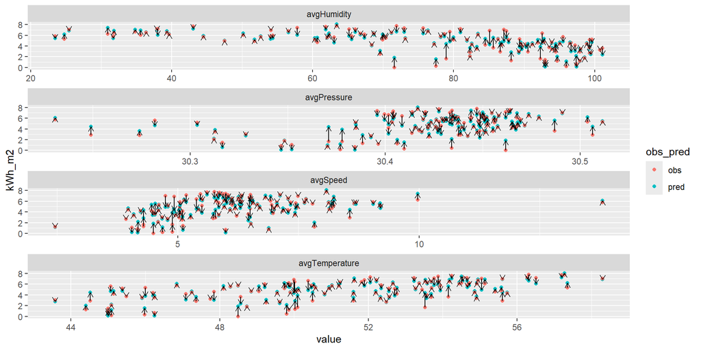

```r
solar_obs <- solarDay |>
  select(Date, kWh_m2, avgTemperature,
         avgPressure, avgHumidity, avgSpeed) |>
  rename("obs" = "kWh_m2") |>
  pivot_longer(cols = -c(Date, obs))
solar_pred <- predict(solar_brnn, solarRescale[,-1])
solar_pred <- tibble(data.frame(Date = solarDay$Date),
                     pred = unscale(solar_pred,
                                     maxim = max(solarDay$kWh_m2),
                                     minim = min(solarDay$kWh_m2)))
solar_pred_long <- solar_pred |>
  inner_join(solar_obs, by = join_by("Date")) |>
  pivot_longer(cols = c(pred, obs),
               names_to = "obs_pred", values_to = "kWh_m2")

p1 <- ggplot(data = solar_pred_long) +
  geom_point(aes(x = value, y = kWh_m2, color = obs_pred)) +
  geom_path(aes(x = value, y = kWh_m2, group = Date),arrow = arrow(ends = "first", length = unit(0.075, "inches"))) +
  facet_wrap(~name, scales = "free", ncol = 1)
p1
```